# Mini Data Analysis Project With datateachr

Eric Liu

October 9, 2021

# 0.1 Introduction

This is a data exploration into the datasets from the datateachr package as well as external datasets from [cBioPortal](https://www.cbioportal.org). Initially, 4 datasets will be chosen to be further explored. We will then choose a single dataset for which we will formulate research questions to address with an in depth analysis.

The primary tool for data cleaning and visualization will be *dplyr* and *ggplot* respectively.

# 0.2 Load required libraries

```r
#packages must first be installed locally before they can be loaded
library(datateachr)
library(tidyverse)
library(readr)
```

# 1.1 Choosing datasets

I have chosen two datasets from datateachr and two external datasets that were of personal interest to me as the starting point for our analysis.

1. apt_buildings
2. cancer_sample
3. MSK-IMPACT Clinical Sequencing Cohort, available [here](https://www.cbioportal.org/study/clinicalData?id=msk_impact_2017)
4. buparlisib and letrozole in ER+ metastatic breast cancer, available [here](https://www.cbioportal.org/study/clinicalData?id=brca_mskcc_2019)

# 1.2 Data overview

We will now use basic R and tidyverse functions to gain a better understanding of the data contained within each dataset. The first two datasets can simply be loaded natively in R using `apt_buildings` and `cancer_sample` as we have already loaded the datateachr package. The last two datasets must be first downloaded and then imported using the readr package. Using the `quick_look` function, we will be able to extract the dimensions, name of the variables, and class of the dataset, as well as whether it contains any NA values.

```r
#function to quickly gain key insights into a dataset
quick_look <- function(df) {
  glimpse(df)
  print(class(df))
  paste("Contains NA?", any(is.na(df)))
}

#first we will look at the apt_buildings dataset from datateachr
apt_buildings <- apt_buildings
quick_look(apt_buildings)
```

```
## Rows: 3,455
## Columns: 37
## $ id                               <dbl> 10359, 10360, 10361, 10362, 10363, 10…
## $ air_conditioning                 <chr> "NONE", "NONE", "NONE", "NONE", "NONE…
## $ amenities                        <chr> "Outdoor rec facilities", "Outdoor po…
## $ balconies                        <chr> "YES", "YES", "YES", "YES", "NO", "NO…
## $ barrier_free_accessibilty_entr   <chr> "YES", "NO", "NO", "YES", "NO", "NO",…
## $ bike_parking                     <chr> "0 indoor parking spots and 10 outdoo…
## $ exterior_fire_escape             <chr> "NO", "NO", "NO", "YES", "NO", NA, "N…
## $ fire_alarm                       <chr> "YES", "YES", "YES", "YES", "YES", "Y…
## $ garbage_chutes                   <chr> "YES", "YES", "NO", "NO", "NO", "NO",…
## $ heating_type                     <chr> "HOT WATER", "HOT WATER", "HOT WATER"…
## $ intercom                         <chr> "YES", "YES", "YES", "YES", "YES", "Y…
## $ laundry_room                     <chr> "YES", "YES", "YES", "YES", "YES", "Y…
## $ locker_or_storage_room           <chr> "NO", "YES", "YES", "YES", "NO", "YES…
```

[output cut: 25 more lines]

```
## [1] "Contains NA? TRUE"
```

```r
#repeat for cancer_sample
cancer_sample <- cancer_sample
quick_look(cancer_sample)
```

```
## Rows: 569
## Columns: 32
## $ ID                      <dbl> 842302, 842517, 84300903, 84348301, 84358402, …
## $ diagnosis               <chr> "M", "M", "M", "M", "M", "M", "M", "M", "M", "…
## $ radius_mean             <dbl> 17.990, 20.570, 19.690, 11.420, 20.290, 12.450…
## $ texture_mean            <dbl> 10.38, 17.77, 21.25, 20.38, 14.34, 15.70, 19.9…
## $ perimeter_mean          <dbl> 122.80, 132.90, 130.00, 77.58, 135.10, 82.57, …
## $ area_mean               <dbl> 1001.0, 1326.0, 1203.0, 386.1, 1297.0, 477.1, …
## $ smoothness_mean         <dbl> 0.11840, 0.08474, 0.10960, 0.14250, 0.10030, 0…
## $ compactness_mean        <dbl> 0.27760, 0.07864, 0.15990, 0.28390, 0.13280, 0…
## $ concavity_mean          <dbl> 0.30010, 0.08690, 0.19740, 0.24140, 0.19800, 0…
## $ concave_points_mean     <dbl> 0.14710, 0.07017, 0.12790, 0.10520, 0.10430, 0…
## $ symmetry_mean           <dbl> 0.2419, 0.1812, 0.2069, 0.2597, 0.1809, 0.2087…
## $ fractal_dimension_mean  <dbl> 0.07871, 0.05667, 0.05999, 0.09744, 0.05883, 0…
## $ radius_se               <dbl> 1.0950, 0.5435, 0.7456, 0.4956, 0.7572, 0.3345…
```

[output cut: 20 more lines]

```
## [1] "Contains NA? FALSE"
```

```r
#we must first import the last 2 data sets, and again look at their features
msk <- read_tsv("msk_impact_2017_clinical_data.tsv")
quick_look(msk)
```

```
## Rows: 10,945
## Columns: 26
## $ `Study ID`                      <chr> "msk_impact_2017", "msk_impact_2017", …
## $ `Patient ID`                    <chr> "P-0000004", "P-0000015", "P-0000023",…
## $ `Sample ID`                     <chr> "P-0000004-T01-IM3", "P-0000015-T01-IM…
## $ `Cancer Type`                   <chr> "Breast Cancer", "Breast Cancer", "Mes…
## $ `Cancer Type Detailed`          <chr> "Breast Invasive Ductal Carcinoma", "B…
## $ `DNA Input`                     <dbl> 250, 198, 250, 250, 250, 250, 250, 250…
## $ `Fraction Genome Altered`       <dbl> 0.2782, 0.3503, 0.1596, 0.3878, 0.0000…
## $ `Matched Status`                <chr> "Matched", "Matched", "Matched", "Matc…
## $ `Metastatic Site`               <chr> NA, "Liver", NA, "Lung", NA, "Peritone…
## $ `Mutation Count`                <dbl> 16, 7, 5, 6, 1, 2, 4, 1, 10, 12, 3, 4,…
## $ `Oncotree Code`                 <chr> "IDC", "IDC", "PEMESO", "UEC", "USC", …
## $ `Overall Survival (Months)`     <dbl> NA, NA, 8.71, 36.75, 8.81, 8.81, NA, N…
## $ `Overall Survival Status`       <chr> "0:LIVING", "1:DECEASED", "1:DECEASED"…
## $ `Primary Tumor Site`            <chr> "Breast", "Breast", "Peritoneum", "Ute…
## $ `Sample Class`                  <chr> "Tumor", "Tumor", "Tumor", "Tumor", "T…
## $ `Sample Collection Source`      <chr> "Outside", "In-House", "In-House", "In…
## $ `Number of Samples Per Patient` <dbl> 1, 1, 1, 1, 2, 2, 1, 1, 1, 1, 1, 2, 2,…
## $ `Sample coverage`               <dbl> 428, 281, 454, 1016, 1161, 1147, 1222,…
## $ `Sample Type`                   <chr> "Primary", "Metastasis", "Primary", "M…
## $ Sex                             <chr> "Female", "Female", "Male", "Female", …
## $ `Smoking History`               <chr> "Unknown", "Never", "Never", "Prev/Cur…
## $ `Somatic Status`                <chr> "Matched", "Matched", "Matched", "Matc…
## $ `Specimen Preservation Type`    <chr> "FFPE", "FFPE", "FFPE", "FFPE", "FFPE"…
## $ `Specimen Type`                 <chr> "Biopsy", "Biopsy", "Biopsy", "Resecti…
## $ `Tumor Purity`                  <dbl> 50, 40, 30, 40, NA, 30, 10, NA, 40, 40…
## $ `Patient's Vital Status`        <chr> "ALIVE", "DECEASED", "DECEASED", "ALIV…
## [1] "spec_tbl_df" "tbl_df"      "tbl"         "data.frame"
```

```
## [1] "Contains NA? TRUE"
```

```r
metastatic_BC <- read_tsv("brca_mskcc_2019_clinical_data.tsv")
quick_look(metastatic_BC)
```

```
## Rows: 70
## Columns: 29
## $ `Study ID`                      <chr> "brca_mskcc_2019", "brca_mskcc_2019", …
## $ `Patient ID`                    <chr> "p_DS_bkm_001", "p_DS_bkm_002", "p_DS_…
## $ `Sample ID`                     <chr> "s_DS_bkm_001_T", "s_DS_bkm_002_T", "s…
## $ `Best Response to Therapy`      <chr> "Stable Disease", "Stable Disease", "P…
## $ `block accession`               <chr> "S09-21571-3D", "07-TJ-947-D", "S10-88…
## $ `Cancer Type`                   <chr> "Breast Cancer", "Breast Cancer", "Bre…
## $ `Cancer Type Detailed`          <chr> "Invasive Breast Carcinoma", "Invasive…
## $ Comments                        <chr> NA, NA, NA, NA, NA, NA, NA, NA, NA, NA…
## $ `Fraction Genome Altered`       <dbl> 0.1565, 0.2533, 0.6218, 0.1038, 0.3070…
## $ `Gene Panel`                    <chr> "IMPACT341", "IMPACT341", "IMPACT341",…
## $ `months on study`               <dbl> 11, 4, 3, 1, 2, 10, 11, 6, 2, 1, 7, 2,…
## $ `Months on Treatment`           <dbl> NA, NA, NA, NA, NA, NA, NA, NA, NA, NA…
## $ `Mutation Count`                <dbl> 7, 8, 7, 10, 5, 8, 5, 5, 6, 7, 7, 10, …
```

[output cut: 17 more lines]

```
## [1] "Contains NA? TRUE"
```

```r
#keept the msk variable names as strings as they could be easily incorporated into markdown text.
```

# 1.3 Choosing 2 of the 4 datasets

The above data exploration has provided us with basic but valuable insights into the data contained within each dataset. All datasets followed the “tibble” convention of having columns as variables and rows as individual observation. Data in this form is clean when it does not contain any missing values.

1. The `apt_buildings` dataset is composed of up to 37 aspects of 3,455 buildings in Toronto. As the data contains NA values, it is not clean and hence why not all 37 aspects will be described for each building.
2. The `cancer_sample` dataset is composed of 32 features of 569 images of cancer samples. As the data does not contain NA values, it is clean.
3. The `msk` dataset is composed of 26 aspects of 10,945 patient enrollments into the MSK-IMPACT tumour sequencing study. As the data contains NA values, it is not clean.
4. The `metastatic_BC` dataset is composed of 29 aspects of 70 patient enrollments into a clincial trial for the drugs buparlisib and letrozole in estrogen receptor-positive, metastatic breast cancer. As the data contains NA values, it is not clean.

From the insights into the dataset that we extracted, I have chosen the `msk` and `metastatic_BC` datasets as they are the only two containing clinical data of cancer patients. This is an area I am passionate about and I hope to pursue a career as an oncologist or translational scientist in the future. As well, while the `cancer_sample` dataset is also related to the field, it contains data derived from machine learning deconvolution of cancer sample images rather than clinical data of the patients themselves. Hence, the 2 external datasets better reflect my personal interests and were chosen.

# 1.4 Choosing a single dataset

Looking at the `msk` dataset, there are several variables that describe a potential outcome of interest, such as `Overall Survival (Months)` or `Metastatic Site`. A potential research question could be “How does `Smoking History` affect the patient’s disease course?”

Looking at the `metastatic_BC` dataset, it appears a variable describing an outcome of interest could be `Best Response to Therapy`. Particularly, a potential research question could be “Is the variable `Fraction Genome Altered` predictive of the patient’s `Best Response to Therapy`?”.

After having formulated research questions for both the datasets, I have chosen the `msk` dataset as it is a larger cohort of patients and includes various types of cancer. On the other hand, the `metastatic_BC` dataset was gather from a clinical study and thus represents a more homogeneous group of patients. The data was also gathered with the hypothesis of testing the effectiveness of the experimental intervention in mind. Thus, I believe the diversity of the `msk` dataset might lend to a more interesting and open-ended exploration, hence why I chose it for the next section of the project.

# 2.1 Data exploration

I will perform 4 data analysis exercises to gain a deeper understanding of the data contained.

**Exercise 1** Filtering of dataset to include only the 4 most common types of cancer.

```r
  most_common_cancer_types <- msk %>%
  group_by(`Cancer Type`) %>%
  summarize(n()) %>%
  arrange(desc(`n()`)) %>%
  head(4) %>%
  select(`Cancer Type`) %>%
  as_vector()

msk_most_common <- msk %>% filter(`Cancer Type` %in% most_common_cancer_types)
```

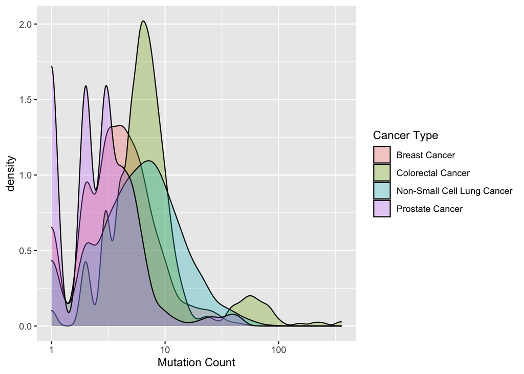

```r
msk_most_common %>% ggplot(aes(x = `Mutation Count`)) +
  geom_density(aes(fill = `Cancer Type`), alpha = 0.3) +
  scale_x_log10() +
  scale_color_discrete()
```

**Exercise 3** Plot of the distribution of `Fraction Genome Altered`

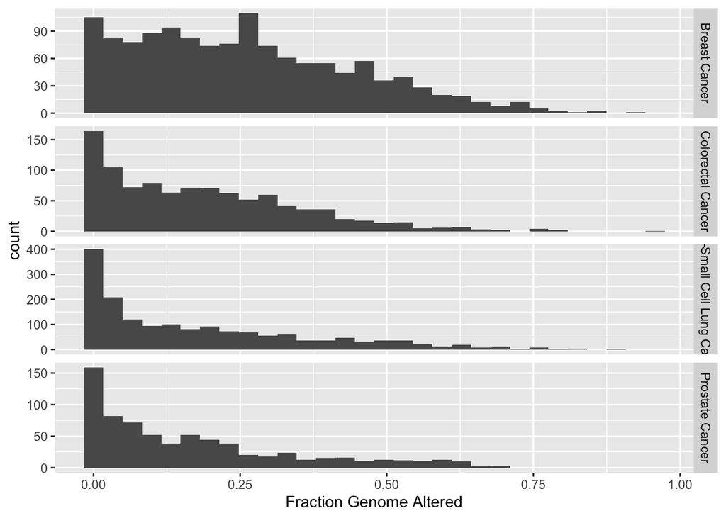

```r
msk_most_common %>% ggplot(aes(x = `Fraction Genome Altered`)) +
  geom_histogram() +
  facet_grid(rows = vars(`Cancer Type`), scales = "free_y")
```

**Exercise 4** Boxplot of `Overall Survival (Months)` across various `Smoking History`.

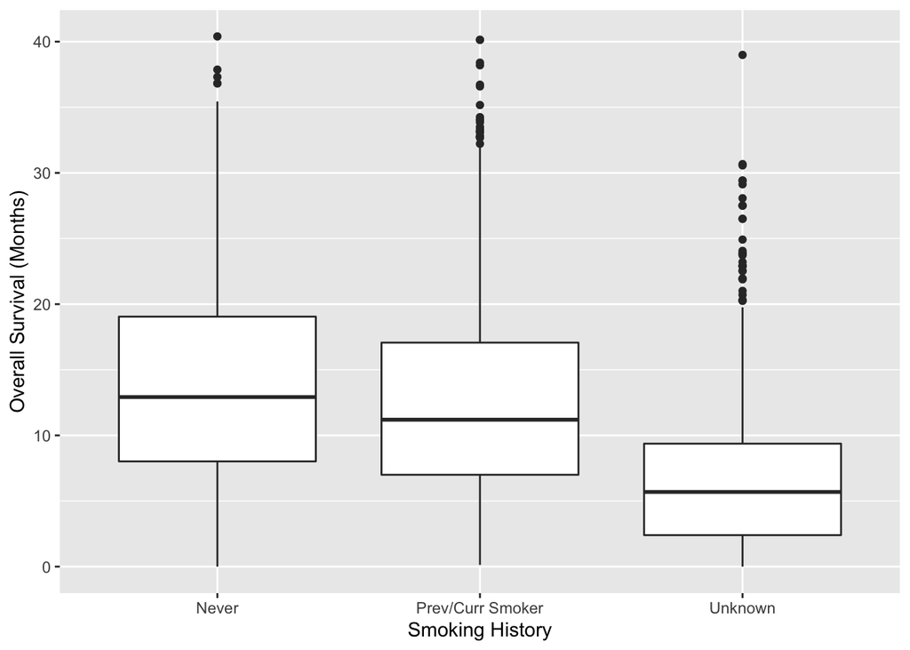

```r
msk_most_common %>% filter(!is.na(`Smoking History`)) %>% ggplot(aes(x = `Smoking History`, y = `Overall Survival (Months)`)) +
  geom_boxplot()
```

# 2.2 Exploration explained

The data exploration exercises performed both made the dataset more manageable to work with as well as offered us a basic understanding of our dataset to formulate research questions.

1. Initially, the `msk` dataset contained 10945 cases of 59 different types of cancers. This woukd make it difficult to stratify for `Cancer Type` in our analysis, so the dataset was filtered to only contain the 4 most common types of cancer, which were: Non-Small Cell Lung Cancer, Breast Cancer, Colorectal Cancer, Prostate Cancer. This reduced the dataset to 4,716 cases, or 43% of the initial dataset.
2. Next, I wanted to see the density distribution of `Mutation Count` for different types of cancer
3. Similarly, I wanted to see the fraction of the genome altered differed for different types of cancer.
4. Finally, I looked at the overall survival for patients according to their `Smoking History`.

# 3.1 Research questions

Following our exploratory data analysis, I formulated the following 4 research questions:

1. What are the genomic and mutational consequences of a patient’s smoking history?
2. What variables are predictive of a patient’s overall survival?
3. Which `Cancer Type` is the most deadly?
4. What are the genomic and mutational differences between primary and Metastasis samples?